# Lecture 10: Relationships Between Variables, Part 2

Nick Huntington-Klein

February 5, 2019

## Recap

- Last time we talked about how to think about the relationship between two variables
- We talked about *dependence* and *correlation*
- As illustrated using proportion tables (`prop.table`), differences in means (`group_by() %>% summarize()`), correlation (`cor`), and graphically with scatterplots (`plot(xvar,yvar)`) and overlaid densities (`plot(density())` followed by `lines(density())`)

## Today

- We’re going to be going much further into *explaining*
- How can we use one variable to *explain* another and what does that mean?
- One way to think about what we’re doing is to translate “how does `X` explain `Y`” as “what would I expect `Y` to look like, given a certain value of `X`?”

## Explanation

- Why do we care?
- Explaining is a very flexible way of understanding the relationship between two variables
- Plus, it lets us put a magnitude on these relationships
- “How much of the variation in earnings is *explained by* education?”
- “How much of the variation in earnings is *not explained by* education?”

## Explanation

- Plus, this will end up being very important when we get to causality
- Think back to this graph from last time:

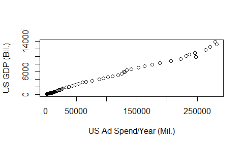

```r
addata <- read.csv('http://www.nickchk.com/ad_spend_and_gdp.csv')
plot(addata$AdSpending,addata$GDP,
     xlab='US Ad Spend/Year (Mil.)',ylab='US GDP (Bil.)')
```

## Explanation

- We know that part of the reason for the relationship we see is *inflation*
- Explanation lets us say things like “*not counting* the parts of ad spend and GDP that are *explained* by inflation, what is the relationship between ad spend and GDP?”
- When we get into causality, this will let us isolate just the parts of the relationship we’re interested in

## Simple Explanation

- So that’s our goal - for different values of `X`, see what `Y` looks like.
- There are *lots* of ways to do this - one of which is called *regression* and you’ll see that in later classes
- In this class we’re going to focus on a very simple approach - simply taking the mean of `Y` for different values of `X`.

## Simple Explanation

- Basically, we’re trying to do a simpler version of this:

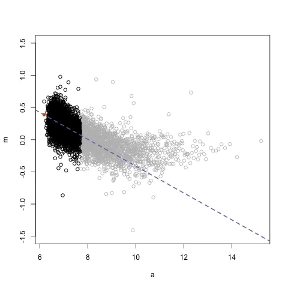

Local Linear Regression

## Simple Explanation

- We already know how to calculate these means - we can do it with `summarize()`
- Let’s use data on demographic info by county in `data(midwest)` and get the average poverty rate by county in each state

```r
library(tidyverse)
data(midwest)
midwest %>% group_by(state) %>% summarize(percbelowpoverty = mean(percbelowpoverty))
```

```
## # A tibble: 5 x 2
##   state percbelowpoverty
##   <chr>            <dbl>
## 1 IL                13.1
## 2 IN                10.3
## 3 MI                14.2
## 4 OH                13.0
## 5 WI                11.9
```

## Simple Explanation

- Now we know what we’d *expect* a county’s poverty rate to be, based on what state it’s in.
- It will be useful for us to have this average in the data frame itself, which we can do by using `group_by()` leading into `mutate()` instead of `summarize()`

```r
midwest <- midwest %>% group_by(state) %>%
  mutate(avebystate = mean(percbelowpoverty))
head(select(midwest,state,county,percbelowpoverty,avebystate))
```

```
## # A tibble: 6 x 4
## # Groups:   state [1]
##   state county    percbelowpoverty avebystate
##   <chr> <chr>                <dbl>      <dbl>
## 1 IL    ADAMS                13.2        13.1
## 2 IL    ALEXANDER            32.2        13.1
## 3 IL    BOND                 12.1        13.1
## 4 IL    BOONE                 7.21       13.1
## 5 IL    BROWN                13.5        13.1
## 6 IL    BUREAU               10.4        13.1
```

## Simple Explanation

- `avebystate` now represents the part of poverty that is *explained by state*
- Whatever’s left over must be the part *unexplained by state*, a.k.a “the residual”

```r
midwest <- mutate(midwest,residual = percbelowpoverty - avebystate)
head(select(midwest,state,county,percbelowpoverty,avebystate,residual))
```

```
## # A tibble: 6 x 5
## # Groups:   state [1]
##   state county    percbelowpoverty avebystate residual
##   <chr> <chr>                <dbl>      <dbl>    <dbl>
## 1 IL    ADAMS                13.2        13.1   0.0750
## 2 IL    ALEXANDER            32.2        13.1  19.2
## 3 IL    BOND                 12.1        13.1  -1.01
## 4 IL    BOONE                 7.21       13.1  -5.87
## 5 IL    BROWN                13.5        13.1   0.444
## 6 IL    BUREAU               10.4        13.1  -2.68
```

## Graphically

- For each value of state, we get the mean. Any deviation from that is the residual

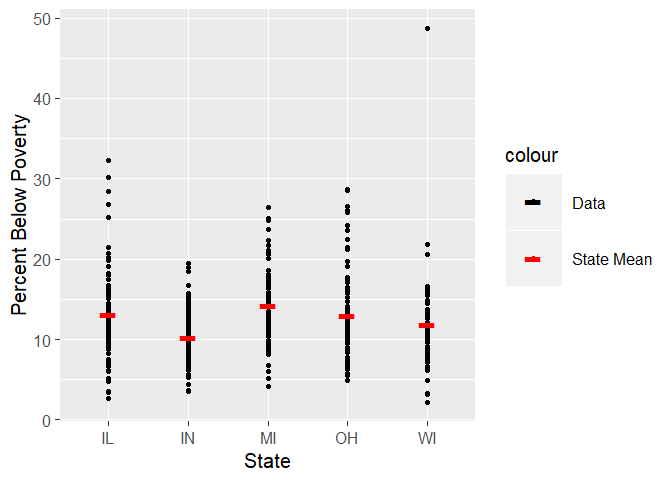

## Graphically

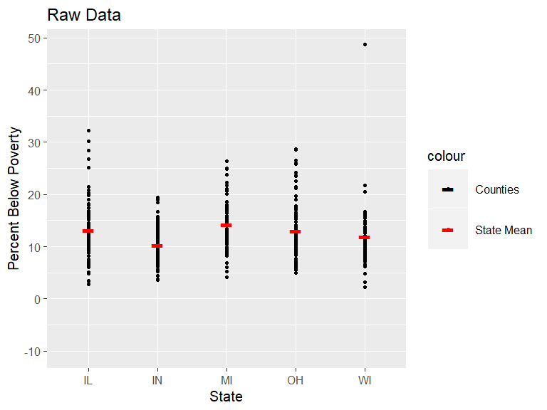

## How much is explained?

- How much of poverty-by-county is explained by the state?
- We do this by seeing how much *variance* is left over after our explanation
- 0.9334186 of the variation in county-level poverty is still there after the explanation. State explained only 1-0.9334186 = 0.0665814 of it!

```r
c(var(midwest$percbelowpoverty),var(midwest$residual))
```

```
## [1] 26.52410 24.75809
```

```r
var(midwest$residual)/var(midwest$percbelowpoverty)
```

```
## [1] 0.9334186
```

## Continuous Variables

- The approach with `summarize(X = mean(X))` works great!
- But think about it with a continuous variable…!

```r
midwest <- midwest %>% group_by(as.factor(percollege)) %>%
  mutate(avebycoll = mean(percbelowpoverty)) %>%
  mutate(collresidual = percbelowpoverty - avebycoll) %>% ungroup()
head(select(midwest,state,county,percbelowpoverty,avebycoll,collresidual))
```

```
## # A tibble: 6 x 5
##   state county    percbelowpoverty avebycoll collresidual
##   <chr> <chr>                <dbl>     <dbl>        <dbl>
## 1 IL    ADAMS                13.2      13.2             0
## 2 IL    ALEXANDER            32.2      32.2             0
## 3 IL    BOND                 12.1      12.1             0
## 4 IL    BOONE                 7.21      7.21            0
## 5 IL    BROWN                13.5      13.5             0
## 6 IL    BUREAU               10.4      10.4             0
```

```r
1-var(midwest$collresidual)/var(midwest$percbelowpoverty)
```

```
## [1] 1
```

## Overfitting

- Imagine I were predicting the height of everyone in the room - first row, first chair? I predict you have the height of the person in the first row, first chair
- I’ll predict perfectly!
- But when the next class comes in, if I reuse the same predictions I’ll be very wrong!
- Meaning that my “predictions” aren’t all that useful
- I’ll do better with *less* flexibility - I’ll just take average height now. Bigger residuals now, but I’ll do a better job predicting the next class

## Continuous Variables

- So in this context, we’re going to do this by splitting the continuous variable `X` up into bins, and taking the mean of `Y` within those bins using `mutate()`.
- We can do this with the `cut()` function with the `breaks` option, which splits the continuous variable into `breaks` bins of equal length

```r
midwest <- midwest %>% mutate(collbins = cut(percollege,breaks=10))
head(midwest %>% select(county,percbelowpoverty,percollege,collbins))
```

```
## # A tibble: 6 x 4
##   county    percbelowpoverty percollege collbins
##   <chr>                <dbl>      <dbl> <fct>
## 1 CLARK                13.4        17.8 (15.5,19.6]
## 2 ST CLAIR             10.9        17.6 (15.5,19.6]
## 3 FOREST               21.8        13.6 (11.4,15.5]
## 4 DAVIESS              15.5        13.2 (11.4,15.5]
## 5 CHAMPAIGN             8.83       13.9 (11.4,15.5]
## 6 SHEBOYGAN             6.49       20.8 (19.6,23.6]
```

## Continuous Variables

- Then, just like before with state, we can use `mutate` to take means within these bins

```r
midwest <- midwest %>% mutate(collbins = cut(percollege,10)) %>%
  group_by(collbins) %>% mutate(avebycoll = mean(percbelowpoverty)) %>% ungroup()
head(midwest %>% select(county,percbelowpoverty,percollege,avebycoll))
```

```
## # A tibble: 6 x 4
##   county    percbelowpoverty percollege avebycoll
##   <chr>                <dbl>      <dbl>     <dbl>
## 1 CLARK                13.4        17.8      11.5
## 2 ST CLAIR             10.9        17.6      11.5
## 3 FOREST               21.8        13.6      13.9
## 4 DAVIESS              15.5        13.2      13.9
## 5 CHAMPAIGN             8.83       13.9      13.9
## 6 SHEBOYGAN             6.49       20.8      10.5
```

## Continuous Variables

- Let’s see our relationship, what’s explained, and what’s not!

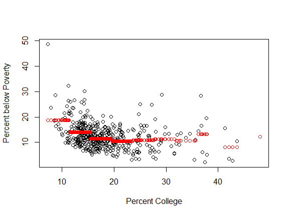

```r
plot(midwest$percollege,midwest$percbelowpoverty,xlab="Percent College",ylab="Percent below Poverty")
points(midwest$percollege,midwest$avebycoll,col='red')
```

## Continuous Variables

- And so how much can we explain of poverty with college percentage in bins?

```r
var(midwest$percbelowpoverty-midwest$avebycoll)
```

```
## [1] 22.04112
```

```r
var(midwest$percbelowpoverty)
```

```
## [1] 26.5241
```

```r
1-var(midwest$percbelowpoverty-midwest$avebycoll)/var(midwest$percbelowpoverty)
```

```
## [1] 0.1690152
```

## Continuous Variables

- Note our approach is sensitive to how many bins we pick. So how many is right?
- More bins = more explained, but more overfitting risk.
- In this class we’re going to be a little arbitrary. But there are good ways to pick bins, and other non-bin ways to do this (future classes!)

```r
for (brks in c(2,10,20,50)) {
  print(1-var(midwest$percbelowpoverty-
                (midwest %>% group_by(cut(percollege,breaks=brks)) %>%
                   mutate(avebycoll = mean(percbelowpoverty)))$avebycoll)/
          var(midwest$percbelowpoverty))
}
```

```
## [1] 0.005783466
## [1] 0.1690152
## [1] 0.2114173
## [1] 0.3168701
```

## Practice

- Get the `BudgetFood` (rename:`BF`) data from `Ecdat` and examine it
- Explain `wfood` with `town` and then with `totexp` (`breaks=10`). For each:
- Create a variable with the predicted/explained values
- Calculate the residuals
- Show the proportion of variance explained
- `plot` the raw data and add red `points` for the explained values
- For `totexp`, also do a `plot` of residuals with a red horizontal line at 0

## Practice answers

```r
library(Ecdat)
data(BudgetFood)
help(BudgetFood)
str(BudgetFood)
BF <- BudgetFood

BF <- BF %>%
  group_by(town) %>%
  mutate(avebytown = mean(wfood)) %>%
  mutate(townresid = wfood - avebytown)
1-var(BF$townresid)/var(BF$wfood)
plot(BF$town,BF$wfood,xlab='Town',ylab='Food as Pct. of Expenditure')
points(BF$town,BF$avebytown,col='red')

BF <- BF %>%
  mutate(expbins = cut(totexp,breaks=10)) %>%
  group_by(expbins) %>%
  mutate(avebyexp = mean(wfood)) %>%
  mutate(expresid = wfood - avebyexp)
1-var(BF$expresid)/var(BF$wfood)
plot(BF$totexp,BF$wfood,xlab='Total Expenditure',ylab='Food as Pct. of Expenditure')
points(BF$totexp,BF$avebyexp,col='red')

plot(BF$totexp,BF$expresid,xlab='Total Expenditure',ylab='Residuals')
abline(0,0,col='red')
```